# The Study Break Diary

A Tiny Princess Diary of Student Survival

Mimi Nguyen

2026-05-13

## Dear Diary, I Need a Break

[figure not shown]

A young girl reacting dramatically, switching between sad and happy emotions

This is a **visual data diary about study breaks**.

It all started with the data collection from Project 2, where we logged patterns and information about study breaks over time. Each row in my data represents one study break that was recorded through my Google Form by either me, my amazing teammate Emily, or our friends. The data records when the break happened, why it was taken, how long it lasted, what activities took place, and how refreshed the student felt afterwards.

Basically, this is a shared diary of us trying to survive study sessions one break at a time.

## Chapter One: The Search for the Perfect Break Length

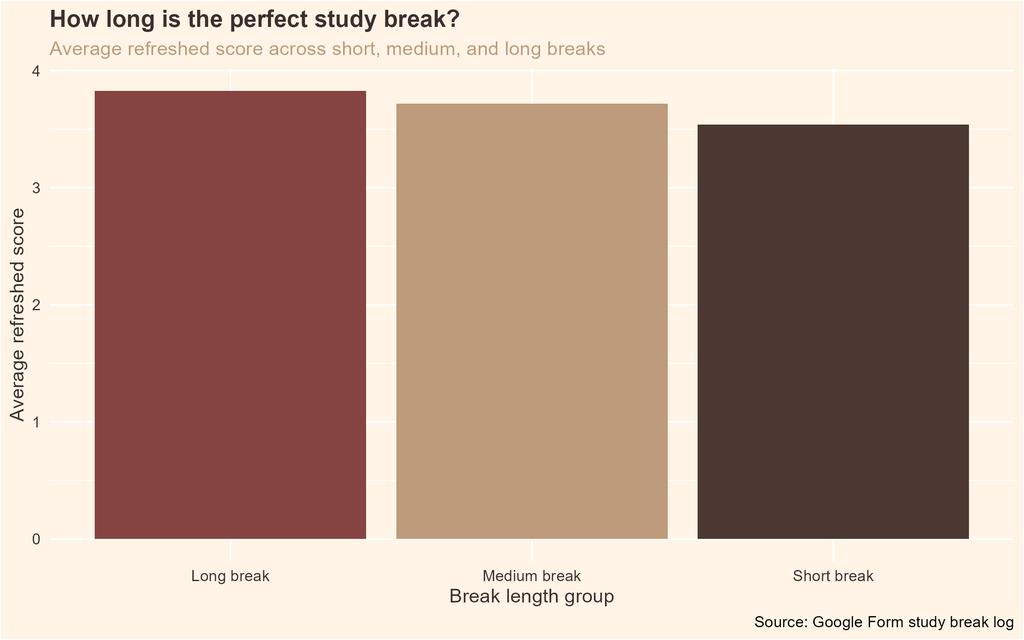

This plot compares how refreshed students felt after **short** (15 minutes or less), **medium** (45 minutes or less), and **long** study breaks (more than 45 minutes).

I wanted to see whether longer breaks actually helped more, or whether there is a point where a break stops being refreshing and starts becoming a small holiday and then leaves us feeling super duper tired and bored to get back to work.

From the visualisation, there is **not a huge difference** in the average refreshed score between the three break length groups. However, there is still a small pattern: as the break gets longer, the average refreshed score seems to increase slightly. This makes sense to me because longer breaks probably give students a bit more time to properly reset before going back to study.

## Chapter Two: The Many Reasons We Hit Pause

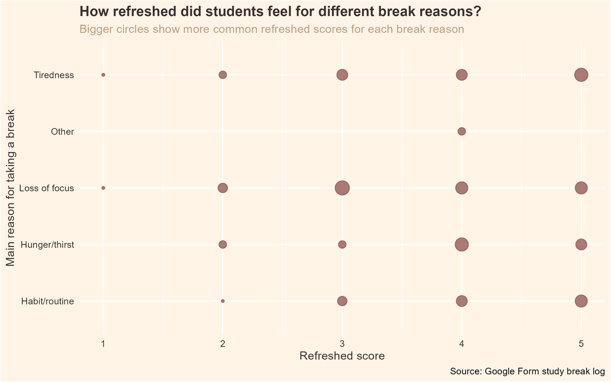

Count plot showing refreshed scores from 1 to 5 for each main reason for taking a study break. Refreshed scores vary across different break reasons, with loss of focus and tiredness having a wider spread. Larger circles indicate that more study breaks had that reason and a refreshed score combination.

This plot looks at **why students took study breaks** and how refreshed they felt afterwards.

The bigger circles show the refreshed scores that appeared more often for each break reason. This makes it easier to see where the responses are clustering, instead of just looking at a table of numbers.

One thing I noticed is that **loss of focus** and **tiredness** have a wider spread of refreshed scores. Some breaks seemed to help, but some clearly did not perform miracles. For **hunger/thirst** and **habit/routine**, more responses seem to sit around the higher refreshed scores, which makes sense because food, drinks, and routine breaks can actually feel like a proper reset.

## Chapter Three: Breaks by the Clock

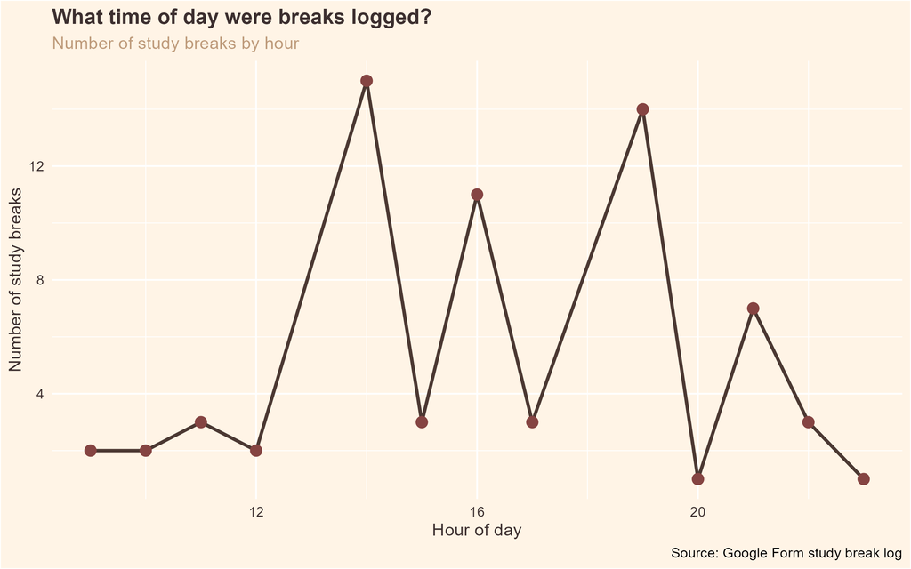

Line plot showing the number of study breaks logged by hour of the day. Study breaks were logged more often in the afternoon and early evening, with peaks around 2 pm and 7 pm.

This plot uses the timestamp from the Google Form entries to show **when study breaks were logged** during the day.

The breaks were not spread evenly across all hours. There are clear peaks in the afternoon (around 2 pm) and early evening (around 7 pm), which honestly feel very believable. That is usually when study energy starts becoming a little questionable.

To me, this gives the data a nice diary feeling. It shows the rhythm of student life: study, take a break, snack, panic and repeat.

## Final Entry: Did the Breaks Help?

Overall, this visual diary shows that study breaks are not just random little pauses. They have their own patterns.

- Longer breaks seemed to have a slightly higher average refreshed score, but the difference was not huge.
- The reason for taking a break also mattered, with some reasons showing a wider range of refreshed scores than others.
- The time plot also showed that breaks were more common during certain parts of the day, especially when study energy was probably starting to disappear.

> So, dear diary, maybe study breaks are not just procrastination. Sometimes they are just survival with snacks, scrolling and emotional recovery.

[figure not shown]

A young girl in a gown and tiara turning around happily.